# ML01-project

# Breast Cancer data analysis

## Introduction

The phenotypes for characterisation are:

```
Sample ID (code number)
Clump thickness
Uniformity of cell size
Uniformity of cell shape
Marginal adhesion
Single epithelial cell size
Number of bare nuclei
Bland chromatin
Number of normal nuclei
Mitosis
Classes, i.e. diagnosis
```

## clean the data

```r
bc_data <- read.table("breast-cancer-wisconsin.data", header = FALSE, sep = ",")
head(bc_data)
```

|  | V1 | V2 | V3 | V4 | V5 | V6 | V7 | V8 | V9 | V10 | V11 |
| --- | --- | --- | --- | --- | --- | --- | --- | --- | --- | --- | --- |
| 1 | 1000025 | 5 | 1 | 1 | 1 | 2 | 1 | 3 | 1 | 1 | 2 |
| 2 | 1002945 | 5 | 4 | 4 | 5 | 7 | 10 | 3 | 2 | 1 | 2 |
| 3 | 1015425 | 3 | 1 | 1 | 1 | 2 | 2 | 3 | 1 | 1 | 2 |
| 4 | 1016277 | 6 | 8 | 8 | 1 | 3 | 4 | 3 | 7 | 1 | 2 |
| 5 | 1017023 | 4 | 1 | 1 | 3 | 2 | 1 | 3 | 1 | 1 | 2 |
| 6 | 1017122 | 8 | 10 | 10 | 8 | 7 | 10 | 9 | 7 | 1 | 4 |

As we can see, the dataset has no header, so we add the collum names in order to have an easier manipulation of the data.

```r
colnames(bc_data) <- c("sample_code_number", "clump_thickness", "uniformity_of_cell_size", "uniformity_of_cell_shape", "marginal_adhesion", "single_epithelial_cell_size", "bare_nuclei", "bland_chromatin", "normal_nucleoli", "mitosis", "classes")
```

We also want to change the name for the response variable

```r
bc_data$classes.num=bc_data$classes
bc_data$classes.num[bc_data$classes.num=="2"] <- 0
bc_data$classes.num[bc_data$classes.num=="4"] <- 1
bc_data$classes[bc_data$classes=="2"] <- "benign"
bc_data$classes[bc_data$classes=="4"] <- "malignant"
head(bc_data)
```

|  | sample_code_number | clump_thickness | uniformity_of_cell_size | uniformity_of_cell_shape | marginal_adhesion | single_epithelial_cell_size | bare_nuclei | bland_chromatin | normal_nucleoli | mitosis | classes | classes.num |
| --- | --- | --- | --- | --- | --- | --- | --- | --- | --- | --- | --- | --- |
| 1 | 1000025 | 5 | 1 | 1 | 1 | 2 | 1 | 3 | 1 | 1 | benign | 0 |
| 2 | 1002945 | 5 | 4 | 4 | 5 | 7 | 10 | 3 | 2 | 1 | benign | 0 |
| 3 | 1015425 | 3 | 1 | 1 | 1 | 2 | 2 | 3 | 1 | 1 | benign | 0 |
| 4 | 1016277 | 6 | 8 | 8 | 1 | 3 | 4 | 3 | 7 | 1 | benign | 0 |
| 5 | 1017023 | 4 | 1 | 1 | 3 | 2 | 1 | 3 | 1 | 1 | benign | 0 |
| 6 | 1017122 | 8 | 10 | 10 | 8 | 7 | 10 | 9 | 7 | 1 | malignant | 1 |

```r
bc_data[bc_data=="?"]<-NA
#length(bc_data[bc_data$bare_nuclei==NA])
nrow(bc_data)-length(complete.cases(bc_data)[complete.cases(bc_data)==TRUE])
```

```
[1] 16
```

```r
length(bc_data$bare_nuclei[is.na(bc_data$bare_nuclei)])
```

```
[1] 16
```

We have 16 missing data that are all in the bc_data$bare_nuclei collunm. As the number of observation with missing data is low compared to the total number of observation, we could just ignore these 16 observations for the rest of the study and loose small amount of data. However, we could also replace the missing values by the mean of the collum. It does not change the global mean but reduces the variance. We can also try to apply some algorith that will guess the value with the MICE library. We could also use the library Amelia but we have to make the asomption that all variables follow a multivariate law.

```r
bc_data_missing<-bc_data
bc_data<-na.omit(bc_data)
bc_data_knn<-bc_data#used in comparison
bc_data[,2:10] <- apply(bc_data[, 2:10], 2, function(x) as.numeric(as.character(x)))
#bc_data$classes <- as.factor(bc_data$classes)
#bc_data$classes <- as.numeric(bc_data$classes)
nrow(bc_data)
```

```
[1] 683
```

Now we have a clean dataset.

## Visualisation

```r
summary(bc_data)
```

```
 sample_code_number clump_thickness  uniformity_of_cell_size
 Min.   :   63375   Min.   : 1.000   Min.   : 1.000
 1st Qu.:  877617   1st Qu.: 2.000   1st Qu.: 1.000
 Median : 1171795   Median : 4.000   Median : 1.000
 Mean   : 1076720   Mean   : 4.442   Mean   : 3.151
 3rd Qu.: 1238705   3rd Qu.: 6.000   3rd Qu.: 5.000
 Max.   :13454352   Max.   :10.000   Max.   :10.000
 uniformity_of_cell_shape marginal_adhesion
 Min.   : 1.000           Min.   : 1.00
 1st Qu.: 1.000           1st Qu.: 1.00
 Median : 1.000           Median : 1.00
 Mean   : 3.215           Mean   : 2.83
 3rd Qu.: 5.000           3rd Qu.: 4.00
 Max.   :10.000           Max.   :10.00
 single_epithelial_cell_size  bare_nuclei     bland_chromatin
 Min.   : 1.000              Min.   : 1.000   Min.   : 1.000
 1st Qu.: 2.000              1st Qu.: 1.000   1st Qu.: 2.000
 Median : 2.000              Median : 1.000   Median : 3.000
 Mean   : 3.234              Mean   : 3.545   Mean   : 3.445
 3rd Qu.: 4.000              3rd Qu.: 6.000   3rd Qu.: 5.000
 Max.   :10.000              Max.   :10.000   Max.   :10.000
 normal_nucleoli    mitosis         classes
 Min.   : 1.00   Min.   : 1.000   Length:683
 1st Qu.: 1.00   1st Qu.: 1.000   Class :character
 Median : 1.00   Median : 1.000   Mode  :character
 Mean   : 2.87   Mean   : 1.603
 3rd Qu.: 4.00   3rd Qu.: 1.000
 Max.   :10.00   Max.   :10.000
  classes.num
 Min.   :0.0000
 1st Qu.:0.0000
 Median :0.0000
 Mean   :0.3499
 3rd Qu.:1.0000
 Max.   :1.0000
```

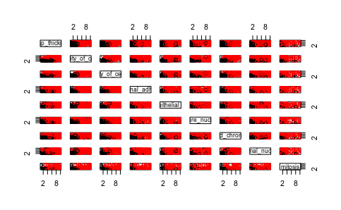

```r
plot(bc_data[,2:10],col=(bc_data$classes.num+1))
```

We dont add the response variable into the scatter plot because box plots are better to display binnary variables

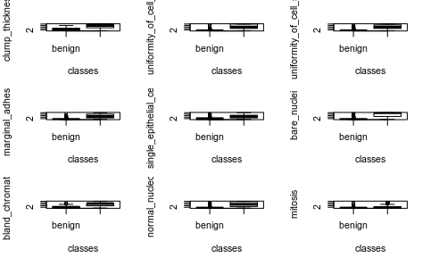

```r
attach(mtcars)
par(mfrow=c(3,3))
for (c in c(2:10)){
  boxplot(bc_data[,c]~classes,data=bc_data,xlab="classes",ylab=colnames(bc_data)[c])
}
```

## Correlation

```r
library(corrplot)
```

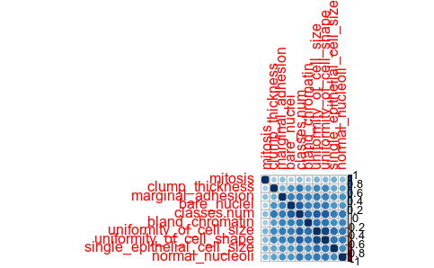

```r
# calculate correlation matrix
corMatMy <- cor(bc_data[, c(-1,-11)])
#corMatMy <- cor(bc_data[, -1])
corrplot(corMatMy, order = "hclust")
```

## Classification

### why do we do classification?

Choose a classifier C(X) that assigns a class label from {benign; malignant} to a future unlabeled observation X. We want to assess the uncertainty in each classification we want to understand the roles of the different predictors.

### Create train subset

We divide the data into test and train dataset. We don’t need to use the function scale() because the data uses already the same range ( from 1 to 10)

```r
n<-nrow(bc_data)
ntrain<-round(2*n/3)
ntest<-n-ntrain
train<-sample(n,ntrain)
bc_data.train<-bc_data[train,]
bc_data.test<-bc_data[-train,]
```

### Bayes Classifier

This probability is called the Bayes error rate. It is the lowest errorprobability that can be achieved by a classifier. It characterizes thedifficulty of the classification task

### K nearest neighbor

#### facts

```r
library(FNN)
```

```r
pred.bc_data.knn<-knn(bc_data.train[,2:10],bc_data.test[,2:10],factor(bc_data.train$classes),k=5)
table(bc_data.test$classes,pred.bc_data.knn)#adjacent error matrix
```

```
           pred.bc_data.knn
            benign malignant
  benign       145         4
  malignant      3        76
```

```r
mean(bc_data.test$classes!=pred.bc_data.knn)
```

```
[1] 0.03070175
```

#### find the optimal k

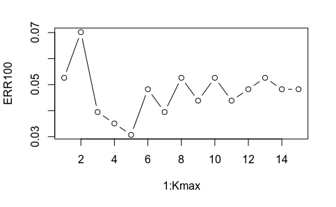

```r
Kmax<-15
ERR100<-c(0,Kmax)
for(k in 1:Kmax){
  classespred<-knn(bc_data.train[,2:10],bc_data.test[,2:10],factor(bc_data.train$classes),k=k)
  ERR100[k]<-mean(bc_data.test$classes!=classespred)
}
plot(1:Kmax,ERR100,type = "b")
```

```r
k_best <- which.min(ERR100)
k_best
```

```
[1] 5
```

#### box plot of optimal k

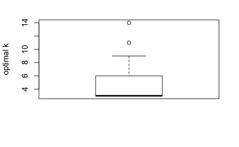

```r
Kmax<-15
max_sim<-20
K_best<-c(0,max_sim)
for(s in 1:max_sim){
  ERR100<-c(0,Kmax)
  train<-sample(n,ntrain)
  bc_data.train<-bc_data[train,]
  bc_data.test<-bc_data[-train,]
  for(k in 1:Kmax){
    classespred<-knn(bc_data.train[,2:10],bc_data.test[,2:10],factor(bc_data.train$classes),k=k)
    ERR100[k]<-mean(bc_data.test$classes!=classespred)
  }
  k_best[s] <- which.min(ERR100)
}
boxplot(k_best,ylab="optimal k")
```

### Linear Discriminant Analysis (LDA)

#### Theory

The parameters to estimates are πk,̂ μk,and ̂Σ

LDA uses the full likelihood based on the joint distribution of X and Y (generative model).

LDA assumes that the data are *Gaussian*. More specifically, it assumes that all classes share the same covariance matrix.

LDA finds linear decision boundaries in a K−1 dimensional subspace. As such, it is not suited if there are higher-order interactions between the independent variables. Although LDA also has a number of parameters proportion top2, it isusually much more stable than QDA. This method is recommended when n is small.

#### Implementation

```r
#bc_data.train.scaled<-scale(bc_data[train,c(-1,-11)])
#bc_data.test.scaled<-scale(bc_data[-train,c(-1,-11)])
```

```r
library(MASS)
lda.bc_data <- lda(classes~. ,data=bc_data.train[,c(-1,-12)])
pred.bc_data.lda<-predict(lda.bc_data,newdata=bc_data.test[,c(-1,-12)])
perf <-table(bc_data.test$classes,pred.bc_data.lda$class)
print(perf)#confusion matrix
```

```
            benign malignant
  benign       151         3
  malignant      7        67
```

```r
1-sum(diag(perf))/nrow(bc_data.test)#mean error rate
```

```
[1] 0.04385965
```

#### Receiver Operating Characteristic (ROC)

In our case we have two classes therefore LDA assigns x to class 2 if xT̂Σ−1(̂μ2−̂μ1 ) >s,where the threshold *s* depends on the estimated prior probabibitie. If the prior probabilities cannot be estimated, or if the model assumption are not verified, a different threshold may give betterresult. The Receiver Operating Characteristic (ROC) curve describes theperformance of the classifier for any value of s. By changing the value of s we can change the confusion matrix values. This allow us to prioritize the true positive rate (sensitivity) and false positive rate (1-specificity).

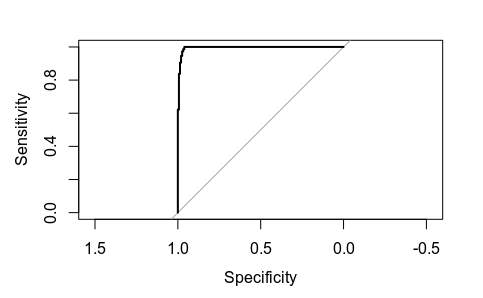

```r
library(pROC)
roc_lda<-roc(bc_data.test$classes,as.vector(pred.bc_data.lda$x))
plot(roc_lda)
```

### Quadratic Discriminant Analysis (QDA)

LDA don’t assumes that all classes share the same covariance matrix. So The parameters to estimates are πk,̂ μk,and ̂Σk. Mean between classes, mean inside classe and empirical variance matrix in class k.

#### Implementation

```r
qda.bc_data <- qda(classes~. ,data=bc_data.train[,c(-1,-12)])
pred.bc_data.qda<-predict(qda.bc_data,newdata=bc_data.test[,c(-1,-12)])
perf <-table(bc_data.test$classes,pred.bc_data.qda$class)
print(perf)#confusion matrix
```

```
            benign malignant
  benign       146         8
  malignant      1        73
```

```r
1-sum(diag(perf))/nrow(bc_data.test)#mean error rate
```

```
[1] 0.03947368
```

### Naive Bayes

#### Theory

For Naive Bayes classifers, we set the covariance matrix to diagonal matrix. This assumption means that the predictors are conditionally independent given the class variable Y. A further simplification is achieved by assuming that the covariancematrices are diagonal and equal:Σ1=···=Σc=Σ=diag(σ21,…,σ2p). Naive Bayes classifiers have a number of parameters proportional to p.They usually outperform other methods when p is very large. #### Implementation

```r
library(naivebayes)
nb.bc_data <- naive_bayes(as.factor(classes)~. ,data=bc_data.train[,c(-1,-12)])
pred.bc_data.nb<-predict(nb.bc_data,newdata=bc_data.test[,c(-1,-12)],type="class")
pred.bc_data.nb.prob<-predict(nb.bc_data,newdata=bc_data.test[,c(-1,-12)],type="prob")
perf <-table(bc_data.test$classes,pred.bc_data.nb)
print(perf)#confusion matrix
```

```
           pred.bc_data.nb
            benign malignant
  benign       148         6
  malignant      1        73
```

```r
1-sum(diag(perf))/nrow(bc_data.test)#mean error rate
```

```
[1] 0.03070175
```

### Logistic regression

Logistic regression uses the conditional likelihood based on the conditional probabilities Pk(x) (discriminative model). logReg models fit by maximizing the conditional likelihood, which is the likelihood function, assuming thexiare fixed. unction`(β) =logL(β)is maximized using an iterative optimizationalgorithm: the Newton-Raphson algorithm. #### Binomial logistic regression As we have only two classes to predict, we can use this classifier

```r
glm.bc_data <- glm(as.factor(classes)~. ,data=bc_data.train[,c(-1,-12)],family=binomial)
pred.bc_data.glm<-predict(glm.bc_data,newdata=bc_data.test[,c(-1,-12)],type="response")
perf <-table(bc_data.test$classes,pred.bc_data.glm>0.5)
print(perf)#confusion matrix
```

```
            FALSE TRUE
  benign      151    3
  malignant     3   71
```

```r
1-sum(diag(perf))/nrow(bc_data.test)#mean error rate
```

```
[1] 0.02631579
```

### Tree classifier

#### Impurity measures Qt

Unlike the tree for the regression, we will not use Qt= MSE within the region. We have three other options: Misclassification error, Gini Index, Entropy. In our casse we have two classes: if p is the proportion of malign in the region Rt then: Misclassification error = 1−max(p,1−p), Gini Index = 2p(1−p), Entropy = −plogp−(1−p)log(1−p). All three are similar, but entropy and the Gini index are differentiable,and hence more amenable to numerical optimization.

Consider a nodetwith sizentwith impurit yQt. For some variable j and split point s, we split t in two nodes, tL and tR, with sizes ntL and ntR, and with impurities QtL and QtR. The average decrease of impurity is ∆(j,s) =Qt−(ntLntQtL+ntRntQtR) If Qt is the entropy, then ∆(j,s)is interpreted as an information gain.We select at each step the splitting variablejand the split pointsthatmaximizes∆(j,s)or, equivalently, that minimizes the average impurity.

When splitting a predictor having q possible unordered values, thereare 2q−1−1 possible partitions of the q values into two groups. All the dichotomies can be explored for small q, but the computations become prohibitive for large q. In the 2-class case, this computation simplifies. We order the predictorlevels according to the proportion falling in outcome class 1. Then wesplit this predictor as if it were an ordered predictor. One can show this gives the optimal split, in terms of entropy or Gini index, among all possible 2q−1−1 splits.

Trees can easily handle qualitative predictors without the need tocreate dummy variables. But the algorith of partitionning tends to favor predictor with many levels: they should be avoided. In our case this is not a problem because every predicto has the same number of level.

#### Implementation

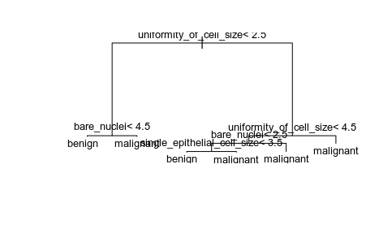

```r
library(rpart)
tree.bc_data<-rpart(classes~.,data=bc_data.train[2:11],method="class",control=rpart.control(xval = 10,minbucket = 5,cp=0))
#x val is number of cross-validations
#minbucket is the minimum number of observations in any terminal <leaf> node.
# cp is complexity parameter. Any split that does not decrease the overall lack of fit by a factor of cp is not attempted.
plot(tree.bc_data,margin = 0.05)
text(tree.bc_data,pretty=0,cex=0.8)
```

```r
pred.bc_data.tree=predict(tree.bc_data,newdata=bc_data.test,type='class')
table(bc_data.test[,"classes"],pred.bc_data.tree)
```

```
           pred.bc_data.tree
            benign malignant
  benign       144        10
  malignant      2        72
```

```r
err<-mean(bc_data.test[,"classes"]!=pred.bc_data.tree)
print(err)
```

```
[1] 0.05263158
```

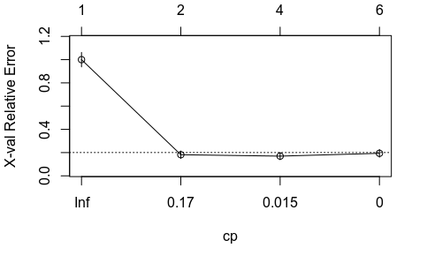

```r
plotcp(tree.bc_data)
```

```r
printcp(tree.bc_data)
```

```
Classification tree:
rpart(formula = classes ~ ., data = bc_data.train[2:11], method = "class",
    control = rpart.control(xval = 10, minbucket = 5, cp = 0))

Variables actually used in tree construction:
[1] bare_nuclei                 single_epithelial_cell_size
[3] uniformity_of_cell_size

Root node error: 165/455 = 0.36264

n= 455

         CP nsplit rel error  xerror     xstd
1 0.8181818      0   1.00000 1.00000 0.062151
2 0.0363636      1   0.18182 0.18182 0.032082
3 0.0060606      3   0.10909 0.16970 0.031067
4 0.0000000      5   0.09697 0.19394 0.033056
```

We see that for a complexity of 0.015, we have the smallest cross validation relative error #### Pruning

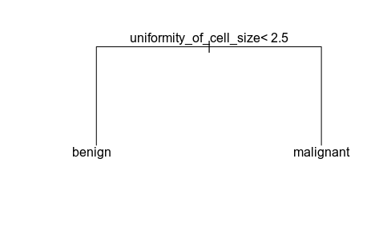

```r
pruned_tree<-prune(tree = tree.bc_data,cp=0.036810)
plot(pruned_tree,margin = 0.1)
text(pruned_tree,pretty=0)
```

```r
pred.pruned_tree=predict(pruned_tree,newdata=bc_data.test[2:11],type='class')
table(bc_data.test[,"classes"],pred.pruned_tree)
```

```
           pred.pruned_tree
            benign malignant
  benign       139        15
  malignant      5        69
```

```r
err1<-mean(bc_data.test[,"classes"]!=pred.pruned_tree)
print(err1)
```

```
[1] 0.0877193
```

### Compare the roc curve

```r
roc_lda<-roc(bc_data.test$classes,as.vector(pred.bc_data.lda$x))
plot(roc_lda)
roc_knn<-roc(bc_data.test$classes,as.vector(as.numeric(pred.bc_data.knn)))
plot(roc_knn,add=TRUE,col='yellow')
```

```r
roc_tree<-roc(bc_data.test$classes,as.vector(as.numeric(pred.bc_data.tree)))
plot(roc_tree,add=TRUE,col='pink')
roc_pruned_tree<-roc(bc_data.test$classes,as.vector(as.numeric(pred.pruned_tree)))
plot(roc_pruned_tree,add=TRUE,col='violet')
```

```r
roc_qda<-roc(bc_data.test$classes,as.vector(pred.bc_data.qda$posterior[,1]))
plot(roc_qda,add=TRUE,col='red')
roc_nb<-roc(bc_data.test$classes,as.vector(pred.bc_data.nb.prob[,1]))
plot(roc_nb,add=TRUE,col='blue')
```

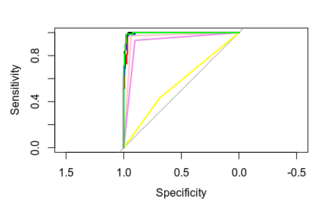

```r
roc_logreg<-roc(bc_data.test$classes,as.vector(pred.bc_data.glm))
plot(roc_logreg,add=TRUE,col='green')
```

```r
vec_auc<-c(auc(roc_lda),auc(roc_knn),auc(roc_tree),auc(roc_pruned_tree),auc(roc_qda),auc(roc_nb),auc(roc_logreg))
AUC=matrix(0,1,7)
for (i in (1:7)){
  print(vec_auc[i])
  AUC[1,i]=vec_auc[i]
}
```

```
[1] 0.9952615
[1] 0.5603721
[1] 0.954019
[1] 0.9175149
[1] 0.98947
[1] 0.9935065
[1] 0.9955247
```

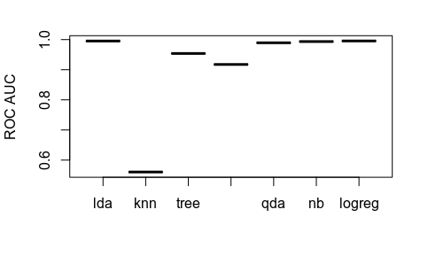

```r
boxplot(AUC,ylab = "ROC AUC", names=c("lda","knn","tree","pruned_tree","qda","nb","logreg"))
```

### Compare on repeated tests

```r
M<-10
ERR<-matrix(0,M,6)
AUC=matrix(0,M,6)
for(i in 1:M){
  #sampling
  train<-sample(n,ntrain)
  bc_data.train<-bc_data[train,]
  bc_data.test<-bc_data[-train,]
  #KNN
  pred.bc_data.knn<-knn(bc_data.train[,2:10],bc_data.test[,2:10],factor(bc_data.train$classes),k=5)
  ERR[i,1]<-mean(bc_data.test$classes!=pred.bc_data.knn)
  #LDA
  lda.bc_data <- lda(classes~. ,data=bc_data.train[,c(-1,-12)])
  pred.bc_data.lda<-predict(lda.bc_data,newdata=bc_data.test[,c(-1,-12)])
  perf <-table(bc_data.test$classes,pred.bc_data.lda$class)
  ERR[i,2]<-1-sum(diag(perf))/nrow(bc_data.test)#mean error rat
  #QDA
  qda.bc_data <- qda(classes~. ,data=bc_data.train[,c(-1,-12)])
  pred.bc_data.qda<-predict(qda.bc_data,newdata=bc_data.test[,c(-1,-12)])
  perf <-table(bc_data.test$classes,pred.bc_data.qda$class)
  ERR[i,3]<-1-sum(diag(perf))/nrow(bc_data.test)#mean error rate
  #NB
  nb.bc_data <- naive_bayes(as.factor(classes)~. ,data=bc_data.train[,c(-1,-12)])
  pred.bc_data.nb<-predict(nb.bc_data,newdata=bc_data.test[,c(-1,-12)],type="class")
  pred.bc_data.nb.prob<-predict(nb.bc_data,newdata=bc_data.test[,c(-1,-12)],type="prob")
  perf <-table(bc_data.test$classes,pred.bc_data.nb)
  ERR[i,4]<-1-sum(diag(perf))/nrow(bc_data.test)#mean error rate
  #LOGREG
  glm.bc_data <- glm(as.factor(classes)~. ,data=bc_data.train[,c(-1,-12)],family=binomial)
  pred.bc_data.glm<-predict(glm.bc_data,newdata=bc_data.test[,c(-1,-12)],type="response")
  perf <-table(bc_data.test$classes,pred.bc_data.glm>0.5)
  ERR[i,5]<-1-sum(diag(perf))/nrow(bc_data.test)#mean error rate
  #PRUNED_TREE
  tree.bc_data<-rpart(classes~.,data=bc_data.train[2:11],method="class",control=rpart.control(xval = 10,minbucket = 5,cp=0))
  pruned_tree<-prune(tree = tree.bc_data,cp=0.036810)
  pred.pruned_tree=predict(pruned_tree,newdata=bc_data.test[2:11],type='class')
  table(bc_data.test[,"classes"],pred.pruned_tree)
  ERR[i,6]<-mean(bc_data.test[,"classes"]!=pred.pruned_tree)

  #AUC
  roc_lda<-roc(bc_data.test$classes,as.vector(pred.bc_data.lda$x))
  roc_knn<-roc(bc_data.test$classes,as.vector(as.numeric(pred.bc_data.knn)))
  roc_pruned_tree<-roc(bc_data.test$classes,as.vector(as.numeric(pred.pruned_tree)))
  roc_qda<-roc(bc_data.test$classes,as.vector(pred.bc_data.qda$posterior[,1]))
  roc_nb<-roc(bc_data.test$classes,as.vector(pred.bc_data.nb.prob[,1]))
  roc_logreg<-roc(bc_data.test$classes,as.vector(pred.bc_data.glm))

  vec_auc<-c(auc(roc_lda),auc(roc_knn),auc(roc_pruned_tree),auc(roc_qda),auc(roc_nb),auc(roc_logreg))
  for (j in (1:6)){
    print(vec_auc[j])
    AUC[i,j]=vec_auc[j]
  }
}
```

```
[1] 0.9973291
[1] 0.9519231
[1] 0.9524573
[1] 0.9916311
[1] 0.9963497
[1] 0.9965278
[1] 0.994761
[1] 0.9623162
[1] 0.9183824
[1] 0.9852941
[1] 0.9924632
[1] 0.9929228
[1] 0.9966426
[1] 0.958074
[1] 0.9286767
```

[output cut: 45 more lines]

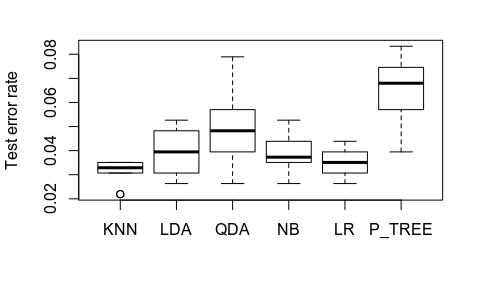

```r
boxplot(ERR,ylab="Test error rate",names=c("KNN","LDA","QDA","NB","LR","P_TREE"))
```

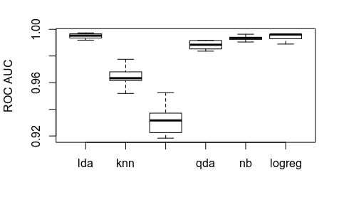

```r
boxplot(AUC,ylab = "ROC AUC", names=c("lda","knn","pruned_tree","qda","nb","logreg"))
```

### Compare using 5 cross validation

```r
#initialize before the loop
K<-5
folds=sample(1:K,ntrain,replace=TRUE)
CV<-matrix(0,K,7)
for(k in (1:K)){
  #Decision Tree
  tree.bc_data<-rpart(classes~.,data=bc_data.train[folds!=k,2:11],method="class",control=rpart.control(xval = 10,minbucket = 5,cp=0))

  pred.bc_data.tree=predict(tree.bc_data,newdata=bc_data.train[folds==k,2:11],type='class')
  CV[k,6]<-sum(bc_data.train[folds==k,'classes']!=pred.bc_data.tree)
  #Decision Tree Pruned
  pruned_tree.bc_data<-prune(tree = tree.bc_data,cp=0.036810)
  pred.bc_data.pruned_tree=predict(pruned_tree.bc_data,newdata=bc_data.train[folds==k,2:11],type='class')
  CV[k,7]<-sum(bc_data.train[folds==k,'classes']!=pred.bc_data.pruned_tree)
  #KNN
  knn.bc_data<-knn(bc_data.train[folds!=k,2:10],bc_data.train[folds==k,2:10],factor(bc_data.train$classes[folds!=k]),k=5)#k=5 this is the best, we choose it before
  CV[k,5]<-sum(bc_data.train$classes[folds==k]!=knn.bc_data)
  #LDA
  lda.bc_data <- lda(classes~. ,data=bc_data.train[folds!=k,c(-1,-12)])#fit
  pred.bc_data.lda<-predict(lda.bc_data,newdata=bc_data.train[folds==k,c(-1,-12)])#pred
  CV[k,1]<-sum(pred.bc_data.lda$class!=bc_data.train$classes[folds==k])
  #QDA
  qda.bc_data <- qda(classes~. ,data=bc_data.train[folds!=k,c(-1,-12)])#fit
  pred.bc_data.qda<-predict(qda.bc_data,newdata=bc_data.train[folds==k,c(-1,-12)])#pred
  CV[k,2]<-sum(pred.bc_data.qda$class!=bc_data.train$classes[folds==k])
  #NB
  nb.bc_data <- naive_bayes(as.factor(classes)~. , data = bc_data.train[folds!=k,c(-1,-12)])#fit
  pred.bc_data.nb<-predict(nb.bc_data,newdata=bc_data.train[folds==k,c(-1,-12)],type="class")#pred
  CV[k,3]<-sum(pred.bc_data.nb!=bc_data.train$classes[folds==k])
  #Logreg
  #glm.bc_data <- glm(as.factor(classes)~. ,data=bc_data.train[,c(-1,-12)],family=binomial)
  #
  logreg.bc_data <- glm(as.factor(classes)~. , data = bc_data.train[folds!=k,c(-1,-12)],family = binomial)#fit
  pred.bc_data.logreg<-predict(logreg.bc_data,newdata=bc_data.train[folds==k,c(-1,-12)],type="response")#pred
  perf <-table(bc_data.train$classes[folds==k],pred.bc_data.logreg<0.5)#just a matrix to have the errors on the diagonals:
  CV[k,4]<- sum(diag(perf))#mean error rate
}
print(CV)
```

```
     [,1] [,2] [,3] [,4] [,5] [,6] [,7]
[1,]    2    3    3    3    3    4    4
[2,]   10    6    4    5    5   11    6
[3,]    2    5    3    1    0    5    5
[4,]    2    5    5    5    4    5    6
[5,]    3    4    2    3    3    1    6
```

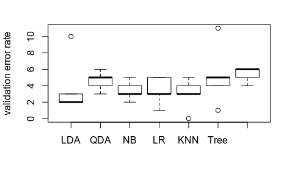

```r
boxplot(CV,ylab='validation error rate',names=c("LDA","QDA","NB","LR","KNN","Tree","Pruned_T"))
```

```r
err_cv=colSums(CV)/ntrain
print(err_cv)
```

```
[1] 0.04175824 0.05054945 0.03736264 0.03736264 0.03296703
[6] 0.05714286 0.05934066
```

```r
function.cross_validation<-function(dataset=bc_data){

  n<-nrow(dataset)
  ntrain<-round(2*n/3)
  ntest<-n-ntrain
  train<-sample(n,ntrain)
  bc_data.train<-dataset[train,]
  bc_data.test<-dataset[-train,]
    #initialize before the loop
  K<-5
  folds=sample(1:K,ntrain,replace=TRUE)
  CV<-matrix(0,K,7)
  for(k in (1:K)){
    #Decision Tree
    tree.bc_data<-rpart(classes~.,data=bc_data.train[folds!=k,2:11],method="class",control=rpart.control(xval = 10,minbucket = 5,cp=0))

    pred.bc_data.tree=predict(tree.bc_data,newdata=bc_data.train[folds==k,2:11],type='class')
    CV[k,6]<-sum(bc_data.train[folds==k,'classes']!=pred.bc_data.tree)
    #Decision Tree Pruned
    pruned_tree.bc_data<-prune(tree = tree.bc_data,cp=0.036810)
    pred.bc_data.pruned_tree=predict(pruned_tree.bc_data,newdata=bc_data.train[folds==k,2:11],type='class')
    CV[k,7]<-sum(bc_data.train[folds==k,'classes']!=pred.bc_data.pruned_tree)
    #KNN
    knn.bc_data<-knn(bc_data.train[folds!=k,2:10],bc_data.train[folds==k,2:10],factor(bc_data.train$classes[folds!=k]),k=5)#k=5 this is the best, we choose it before
    CV[k,5]<-sum(bc_data.train$classes[folds==k]!=knn.bc_data)
    #LDA
    lda.bc_data <- lda(classes~. ,data=bc_data.train[folds!=k,c(-1,-12)])#fit
    pred.bc_data.lda<-predict(lda.bc_data,newdata=bc_data.train[folds==k,c(-1,-12)])#pred
    CV[k,1]<-sum(pred.bc_data.lda$class!=bc_data.train$classes[folds==k])
    #QDA
    qda.bc_data <- qda(classes~. ,data=bc_data.train[folds!=k,c(-1,-12)])#fit
    pred.bc_data.qda<-predict(qda.bc_data,newdata=bc_data.train[folds==k,c(-1,-12)])#pred
    CV[k,2]<-sum(pred.bc_data.qda$class!=bc_data.train$classes[folds==k])
    #NB
    nb.bc_data <- naive_bayes(as.factor(classes)~. , data = bc_data.train[folds!=k,c(-1,-12)])#fit
    pred.bc_data.nb<-predict(nb.bc_data,newdata=bc_data.train[folds==k,c(-1,-12)],type="class")#pred
    CV[k,3]<-sum(pred.bc_data.nb!=bc_data.train$classes[folds==k])
    #Logreg
    #glm.bc_data <- glm(as.factor(classes)~. ,data=bc_data.train[,c(-1,-12)],family=binomial)
    #
    logreg.bc_data <- glm(as.factor(classes)~. , data = bc_data.train[folds!=k,c(-1,-12)],family = binomial)#fit
    pred.bc_data.logreg<-predict(logreg.bc_data,newdata=bc_data.train[folds==k,c(-1,-12)],type="response")#pred
    perf <-table(bc_data.train$classes[folds==k],pred.bc_data.logreg<0.5)#just a matrix to have the errors on the diagonals:
    CV[k,4]<- sum(diag(perf))#mean error rate

  }
  print(CV)
  boxplot(CV,ylab='validation error rate',names=c("LDA","QDA","NB","LR","KNN","Tree","Pruned_T"))
  err_cv=colSums(CV)/ntrain
  print(err_cv)
}
```

```
glm.fit: fitted probabilities numerically 0 or 1 occurred
```

```
     [,1] [,2] [,3] [,4] [,5] [,6] [,7]
[1,]    1    2    2    1    0    1    2
[2,]    5    5    6    5    4    4    5
[3,]    5    6    5    3    3    7    7
[4,]    3    3    2    2    3    4    5
[5,]    3    1    1    1    3    1    2
[1] 0.03736264 0.03736264 0.03516484 0.02637363 0.02857143
[6] 0.03736264 0.04615385
```

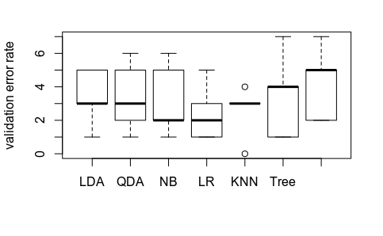

```r
function.cross_validation()
```

## Regression for a dataset without missing values

```r
reg<- lm(bare_nuclei ~. , data=bc_data[,2:10])
pred<-predict(reg,newdata=bc_data_missing[is.na(bc_data_missing$bare_nuclei),2:10])
print(length(pred))
```

```
[1] 16
```

```
     [,1] [,2] [,3] [,4] [,5] [,6] [,7]
[1,]    6    5    4    5    5    9    9
[2,]    6    7    5    5    4    6    6
[3,]    3    4    3    4    3    8    6
[4,]    3    5    2    2    0    6    7
[5,]    5    2    1    5    5    3    8
[1] 0.04935622 0.04935622 0.03218884 0.04506438 0.03648069
[6] 0.06866953 0.07725322
```

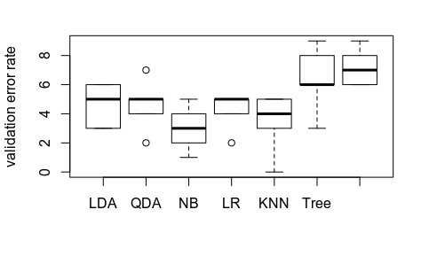

```r
bc_data_missing_lm<-bc_data_missing
bc_data_missing_lm[,"bare_nuclei"]<-as.numeric(bc_data_missing[,"bare_nuclei"])
bc_data_missing_lm[is.na(bc_data_missing$bare_nuclei),"bare_nuclei"]<-pred
#print(bc_data_missing[is.na(bc_data_missing$bare_nuclei),2:10])
#for( i in bc_data_missing[is.na(bc_data_missing$bare_nuclei),2:10]){
#  print(length(i[1]))
#  print(i[1])
#  print(i)
  #i<-predict(reg,newdata=bc_data_missing[is.na(bc_data_missing$bare_nuclei),2:10])
#}
function.cross_validation(bc_data_missing_lm)
```

```r
bc_data_missing_knn<-bc_data_missing
for (i in 1:ncol(bc_data_missing_knn)){
  if (class(bc_data_missing_knn[5,i])=='factor'){
    bc_data_missing_knn[,i] = as.numeric(bc_data_missing_knn[,i])
  }
}
for (i in 1:ncol(bc_data_knn)){
  if (class(bc_data_knn[5,i])=='factor'){
    bc_data_knn[,i] = as.numeric(bc_data_knn[,i])
  }
}
bc_data.train2<-scale(bc_data_knn[,-11])
y.train<-bc_data_knn$bare_nuclei
#print(y.train)
#print(bc_data.train2)
reg<-knn.reg(train=bc_data.train2, y=y.train, k = 5)# on applique le model knn en se basant sur le training valeurs on fait les test sur la partie réservée. y est la réponse des valeur train
#mean((y.test-reg$pred)^2) # = Mean squared error
#plot(y.test,reg$pred,xlab='y',ylab='prediction')
#si les point sont sur la ligne x=y c'est que le aleur prédite est la même que la vraie valuer
#abline(0,1)
knn.predict(train=bc_data.train2, bc_data_missing_knn, y=y.train, k=5)
```

[output not shown]

# REGRESSION

```r
#Clean data
bc_data <- read.table("breast-cancer-wisconsin.data", header = FALSE, sep = ",")
head(bc_data)
```

|  | V1 | V2 | V3 | V4 | V5 | V6 | V7 | V8 | V9 | V10 | V11 |
| --- | --- | --- | --- | --- | --- | --- | --- | --- | --- | --- | --- |
| 1 | 1000025 | 5 | 1 | 1 | 1 | 2 | 1 | 3 | 1 | 1 | 2 |
| 2 | 1002945 | 5 | 4 | 4 | 5 | 7 | 10 | 3 | 2 | 1 | 2 |
| 3 | 1015425 | 3 | 1 | 1 | 1 | 2 | 2 | 3 | 1 | 1 | 2 |
| 4 | 1016277 | 6 | 8 | 8 | 1 | 3 | 4 | 3 | 7 | 1 | 2 |
| 5 | 1017023 | 4 | 1 | 1 | 3 | 2 | 1 | 3 | 1 | 1 | 2 |
| 6 | 1017122 | 8 | 10 | 10 | 8 | 7 | 10 | 9 | 7 | 1 | 4 |

```r
colnames(bc_data) <- c("sample_code_number", "clump_thickness", "uniformity_of_cell_size", "uniformity_of_cell_shape", "marginal_adhesion", "single_epithelial_cell_size", "bare_nuclei", "bland_chromatin", "normal_nucleoli", "mitosis", "classes")
bc_data$classes.num=bc_data$classes # we copie the class column and name it classes.num
bc_data$classes.num[bc_data$classes.num=="2"] <- 0
bc_data$classes.num[bc_data$classes.num=="4"] <- 1
bc_data$classes[bc_data$classes=="2"] <- "benign"
bc_data$classes[bc_data$classes=="4"] <- "malignant"
head(bc_data)
```

|  | sample_code_number | clump_thickness | uniformity_of_cell_size | uniformity_of_cell_shape | marginal_adhesion | single_epithelial_cell_size | bare_nuclei | bland_chromatin | normal_nucleoli | mitosis | classes | classes.num |
| --- | --- | --- | --- | --- | --- | --- | --- | --- | --- | --- | --- | --- |
| 1 | 1000025 | 5 | 1 | 1 | 1 | 2 | 1 | 3 | 1 | 1 | benign | 0 |
| 2 | 1002945 | 5 | 4 | 4 | 5 | 7 | 10 | 3 | 2 | 1 | benign | 0 |
| 3 | 1015425 | 3 | 1 | 1 | 1 | 2 | 2 | 3 | 1 | 1 | benign | 0 |
| 4 | 1016277 | 6 | 8 | 8 | 1 | 3 | 4 | 3 | 7 | 1 | benign | 0 |
| 5 | 1017023 | 4 | 1 | 1 | 3 | 2 | 1 | 3 | 1 | 1 | benign | 0 |
| 6 | 1017122 | 8 | 10 | 10 | 8 | 7 | 10 | 9 | 7 | 1 | malignant | 1 |

```r
bc_data[bc_data=="?"]<-NA
nrow(bc_data)-length(complete.cases(bc_data)[complete.cases(bc_data)==TRUE])
```

```
[1] 16
```

```r
length(bc_data$bare_nuclei[is.na(bc_data$bare_nuclei)])
```

```
[1] 16
```

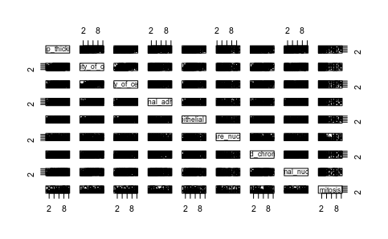

```r
bc_data_sansna<-na.omit(bc_data)
# We want to predict the bare nuclei
data<-bc_data_sansna[,2:10]
plot(data)
```

```r
#on va essayer de prédire toute la colonne bare nuclei comme ça
library('FNN')
for (i in 1:ncol(data)){
  if (class(data[5,i])=='factor'){
    data[,i] = as.numeric(data[,i])
    print(c(i, "DONE"))

  }
  print(c(i,class(data[,i])))
}
```

```
[1] "1"       "integer"
[1] "2"       "integer"
[1] "3"       "integer"
[1] "4"       "integer"
[1] "5"       "integer"
[1] "6"    "DONE"
[1] "6"       "numeric"
[1] "7"       "integer"
[1] "8"       "integer"
[1] "9"       "integer"
```

```r
n<-nrow(data)
ntrain<-round(2*n/3)
ntest<-n-ntrain
train<-sample(n,ntrain)
bc_data.train<-data[train,]
bc_data.train2<-scale(bc_data.train)
y.train<-bc_data.train$bare_nuclei
bc_data.test<-data[-train,]
bc_data.test2<-scale(bc_data.test)
y.test<-bc_data.test$bare_nuclei
"x.train<-scale(data[data$train==T,1:4]) #on garde que les colonnes 1,2,3 et4 où train = true
summary(x.train)
y.train<-data[data$train==T,5]# que la colonne lpsa où train = true
y.train
x.tst<-scale(data[data$train==F,1:4])#les 4 premieres colonnes où train =F
y.tst<-data[data$train==F,5]# que la colonne lpsa où train = f"
```

```
[1] "x.train<-scale(data[data$train==T,1:4]) #on garde que les colonnes 1,2,3 et4 où train = true\nsummary(x.train)\ny.train<-data[data$train==T,5]# que la colonne lpsa où train = true \ny.train\nx.tst<-scale(data[data$train==F,1:4])#les 4 premieres colonnes où train =F\ny.tst<-data[data$train==F,5]…
```

```r
class(bc_data[,2])
```

```
[1] "integer"
```

```r
reg<-knn.reg(train=bc_data.train2, test = bc_data.test2, y=y.train, k = 5)# on applique le model knn en se basant sur le training valeurs on fait les test sur la partie réservée. y est la réponse des valeur train
mean((y.test-reg$pred)^2) # = Mean squared error
```

```
[1] 0.2231579
```

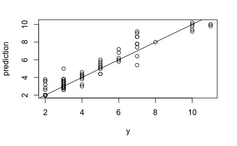

```r
plot(y.test,reg$pred,xlab='y',ylab='prediction')
#si les point sont sur la ligne x=y c'est que le aleur prédite est la même que la vraie valuer
abline(0,1)
```

```r
reg<- lm(bare_nuclei ~. , data=bc_data.train)
reg
```

```
Call:
lm(formula = bare_nuclei ~ ., data = bc_data.train)

Coefficients:
                (Intercept)              clump_thickness      uniformity_of_cell_size     uniformity_of_cell_shape            marginal_adhesion  single_epithelial_cell_size
                    1.84576                      0.11125                      0.05845                      0.12763                     -0.04402                      0.03567
            bland_chromatin              normal_nucleoli                      mitosis
                    0.03150                      0.12245                     -0.03722
```

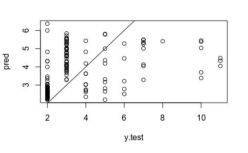

```r
pred<-predict(reg,newdata=bc_data.test)
plot(y.test,pred)
abline(0,1)
```

```r
mse<-mean((y.test-pred)^2)
mse
```

```
[1] 2.947479
```

```r
reg<- lm(bare_nuclei ~. , data=bc_data.train)
reg
pred<-predict(reg,newdata=bc_data.test)
plot(y.test,pred)
abline(0,1)

mse<-mean((y.test-pred)^2)
mse
```

[output not shown]